# AIML_ML_Project_Full_Code_Notebook_working_copy

### Model Building

```
       Model  Accuracy    Recall  Precision        F1   ROC-AUC
0  DT — Base  0.982667  0.923611   0.898649  0.910959  0.956275
```

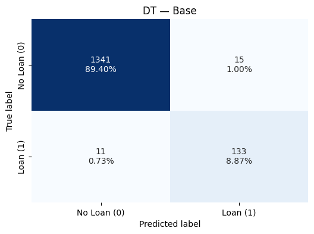

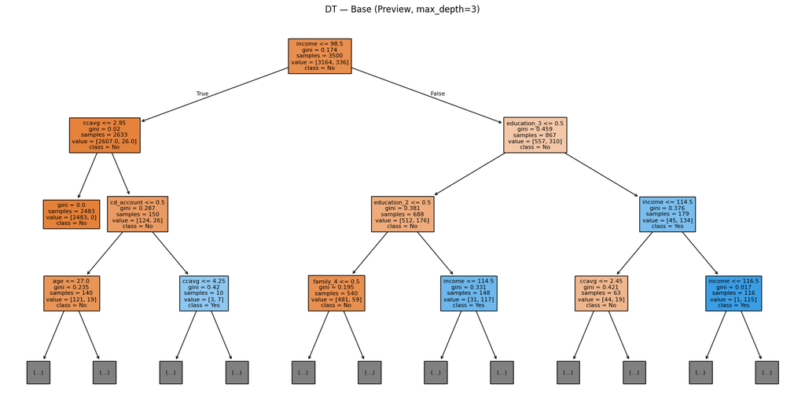

```
Pre-Pruning best params: {'model__max_depth': 3, 'model__min_samples_leaf': 1, 'model__min_samples_split': 2}
Pre-Pruning CV Recall: 0.9822
             Model  Accuracy  Recall  Precision        F1   ROC-AUC
0  DT — Pre-Pruned      0.79     1.0   0.313725  0.477612  0.967949
```

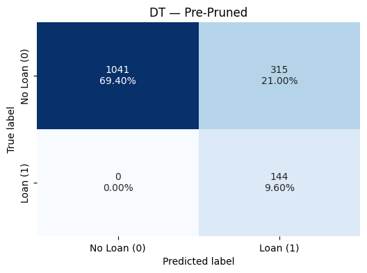

```
Post-Pruning best ccp_alpha: {'model__ccp_alpha': np.float64(0.02307469247840317)}
Post-Pruning CV Recall: 0.9882
              Model  Accuracy  Recall  Precision        F1   ROC-AUC
0  DT — Post-Pruned  0.784667     1.0   0.308351  0.471358  0.891334
```

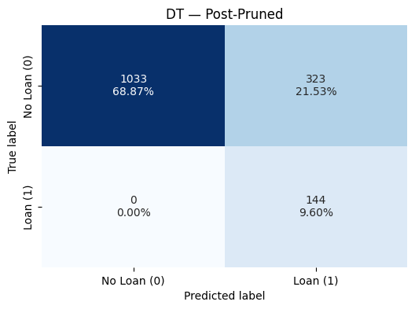

|  | Model | Accuracy | Recall | Precision | F1 | ROC-AUC |
| --- | --- | --- | --- | --- | --- | --- |
| 1 | DT — Pre-Pruned | 0.790000 | 1.000000 | 0.313725 | 0.477612 | 0.967949 |
| 2 | DT — Post-Pruned | 0.784667 | 1.000000 | 0.308351 | 0.471358 | 0.891334 |
| 0 | DT — Base | 0.982667 | 0.923611 | 0.898649 | 0.910959 | 0.956275 |

```python
# =========================================
# Decision Tree Trio (Base / Pre / Post)
# Assumptions:
# - df2 already contains 'region' (from zipcode first 2 digits) and no 'zipcode'
# - Keep BOTH 'age' and 'experience' (experience negatives clipped to 0)
# - Evaluation helpers are defined: model_performance_classification, plot_cm
# =========================================

import numpy as np
import pandas as pd
import matplotlib.pyplot as plt
import seaborn as sns

from sklearn.model_selection import train_test_split, GridSearchCV
from sklearn.compose import ColumnTransformer
from sklearn.preprocessing import OneHotEncoder
from sklearn.pipeline import Pipeline
from sklearn.tree import DecisionTreeClassifier, plot_tree

# -----------------------------
# 0) Modeling prep (simple & safe)
# -----------------------------
dfm = df2.copy()

# Keep both age & experience; only fix negatives in experience
if 'experience' in dfm.columns:
    dfm['experience'] = dfm['experience'].clip(lower=0)

# Features / target
X = dfm.drop(columns=['personal_loan'])
y = dfm['personal_loan']

# Column groups (ensure region is categorical; zipcode is already gone)
cat_cols = [c for c in ['family','education','region'] if c in X.columns]
bin_cols = [c for c in ['securities_account','cd_account','online','creditcard'] if c in X.columns]
num_cols = [c for c in ['age','experience','income','ccavg','mortgage'] if c in X.columns]

# One-hot encode categoricals; numerics & binaries passthrough (trees don't need scaling)
preprocessor = ColumnTransformer(
    transformers=[('cat', OneHotEncoder(drop='first', handle_unknown='ignore'), cat_cols)],
    remainder='passthrough'
)

# Stratified split due to class imbalance
X_train, X_test, y_train, y_test = train_test_split(
    X, y, test_size=0.30, random_state=42, stratify=y
)

# Utility to recover feature names after ColumnTransformer (for importances / plotting)
def get_feature_names_after_ct(cat_cols, num_cols, bin_cols, fitted_pipe):
    ohe = fitted_pipe.named_steps['prep'].named_transformers_['cat']
    cat_names = ohe.get_feature_names_out(cat_cols) if cat_cols else np.array([])
    remainder_names = np.array(num_cols + bin_cols)
    return np.concatenate([cat_names, remainder_names])

# ==========================================================
# 1) Decision Tree — Base Model (no pruning, true baseline)
#    Keep defaults to show baseline behavior. No class_weight.
# ==========================================================
dt_base = Pipeline(steps=[
    ('prep', preprocessor),
    ('model', DecisionTreeClassifier(
        criterion='gini',
        random_state=42
    ))
])
dt_base.fit(X_train, y_train)

perf_base = model_performance_classification(dt_base, X_test, y_test, name="DT — Base")
print(perf_base)
plot_cm(dt_base, X_test, y_test, title="DT — Base")

# Optional: quick preview plot at shallow depth for readability
try:
    feat_names = get_feature_names_after_ct(cat_cols, num_cols, bin_cols, dt_base)
    plt.figure(figsize=(20, 10))
    out = plot_tree(dt_base.named_steps['model'], feature_names=feat_names,
                    class_names=["No","Yes"], filled=True, fontsize=8, max_depth=3)
    # Add arrows (FAQ tip)
    for o in out:
        arrow = getattr(o, "arrow_patch", None)
        if arrow is not None:
            arrow.set_edgecolor('black')
            arrow.set_linewidth(1)
    plt.title("DT — Base (Preview, max_depth=3)")
    plt.show()
except Exception as e:
    print("Tree preview skipped:", e)

# ==========================================================
# 2) Decision Tree — Pre-Pruning
#    Constrain complexity BEFORE overfitting; use class_weight='balanced' to lift recall.
# ==========================================================
dt_pre = Pipeline(steps=[
    ('prep', preprocessor),
    ('model', DecisionTreeClassifier(
        criterion='gini',
        class_weight='balanced',
        random_state=42
    ))
])

param_grid_pre = {
    'model__max_depth': [3, 4, 5, 6, 8, None],
    'model__min_samples_split': [2, 10, 25],
    'model__min_samples_leaf': [1, 5, 10, 20],
}

grid_pre = GridSearchCV(
    estimator=dt_pre,
    param_grid=param_grid_pre,
    scoring='recall',   # <<< maximize recall
    cv=5,
    n_jobs=-1,
    verbose=0
)
grid_pre.fit(X_train, y_train)

best_dt_pre = grid_pre.best_estimator_
print("Pre-Pruning best params:", grid_pre.best_params_)
print("Pre-Pruning CV Recall:", round(grid_pre.best_score_, 4))

perf_pre = model_performance_classification(best_dt_pre, X_test, y_test, name="DT — Pre-Pruned")
print(perf_pre)
plot_cm(best_dt_pre, X_test, y_test, title="DT — Pre-Pruned")

# ==========================================================
# 3) Decision Tree — Post-Pruning (Cost-Complexity, ccp_alpha)
#    Fit, compute pruning path alphas, then cross-validate ccp_alpha for best recall.
# ==========================================================
# Fit preprocessor on training to get transformed X for pruning path
X_train_transformed = preprocessor.fit_transform(X_train)

dt_for_path = DecisionTreeClassifier(
    criterion='gini',
    class_weight='balanced',
    random_state=42
)
# Use the transformed training set to compute pruning path
path = dt_for_path.cost_complexity_pruning_path(X_train_transformed, y_train)
# FAQ note: take absolute values
ccp_alphas_raw = np.abs(path.ccp_alphas)
ccp_alphas_raw = np.unique(ccp_alphas_raw)

# Candidate alphas (exclude last which prunes to root)
if len(ccp_alphas_raw) > 1:
    ccp_alphas = ccp_alphas_raw[:-1]
else:
    ccp_alphas = ccp_alphas_raw

# Subsample to ~25 alphas if many
step = max(1, len(ccp_alphas)//25)
ccp_candidates = list(ccp_alphas[::step]) if len(ccp_alphas) > 0 else [0.0]
if 0.0 not in ccp_candidates:
    ccp_candidates = [0.0] + ccp_candidates

dt_post = Pipeline(steps=[
    ('prep', preprocessor),  # refit inside CV folds
    ('model', DecisionTreeClassifier(
        criterion='gini',
        class_weight='balanced',
        random_state=42
    ))
])

param_grid_post = {'model__ccp_alpha': ccp_candidates}

grid_post = GridSearchCV(
    estimator=dt_post,
    param_grid=param_grid_post,
    scoring='recall',   # <<< maximize recall
    cv=5,
    n_jobs=-1,
    verbose=0
)
grid_post.fit(X_train, y_train)

best_dt_post = grid_post.best_estimator_
print("Post-Pruning best ccp_alpha:", grid_post.best_params_)
print("Post-Pruning CV Recall:", round(grid_post.best_score_, 4))

perf_post = model_performance_classification(best_dt_post, X_test, y_test, name="DT — Post-Pruned")
print(perf_post)
plot_cm(best_dt_post, X_test, y_test, title="DT — Post-Pruned")

# -----------------------------
# 4) Compare the three models
# -----------------------------
perf_table = pd.concat([perf_base, perf_pre, perf_post], ignore_index=True)
display(perf_table.sort_values('Recall', ascending=False))
```

### 📊 Interpretation of Model Results (Decision Trees)

[output not shown]

## 🔧 Model Performance Improvement

Our initial Decision Tree models provided valuable insights:

- **Pre-Pruned DT** maximized recall (1.0) but suffered from very low precision (~0.31).
- **Base DT** achieved high precision (~0.90) but failed to meet our recall objective (~0.92).
- **Post-Pruned DT** simplified the tree but reduced discriminative power (ROC-AUC ~0.89).

To improve performance while prioritizing recall, we can explore several techniques:

1. **Probability Threshold Tuning** – adjust the decision threshold to balance recall and precision.
2. **Ensemble Models** – use Random Forests, Gradient Boosted Trees (XGBoost/LightGBM) for more robust recall.
3. **Feature Engineering** – create interaction terms or bin continuous variables (e.g., income groups).
4. **Class Imbalance Handling** – apply SMOTE, undersampling, or cost-sensitive learning.
5. **Model Comparison** – benchmark tree-based models against Logistic Regression and Ensemble methods.

## Model Performance Improvement

```
Selected threshold: 0.000 (Recall target ≥ 1.0)
                               Model  Threshold  Accuracy  Recall  Precision  \
0  DT — Pre-Pruned (Threshold-Tuned)        0.0     0.096     1.0      0.096

         F1
0  0.175182
```

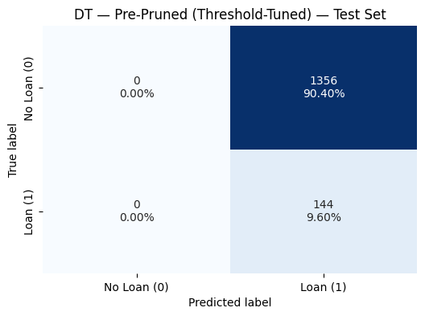

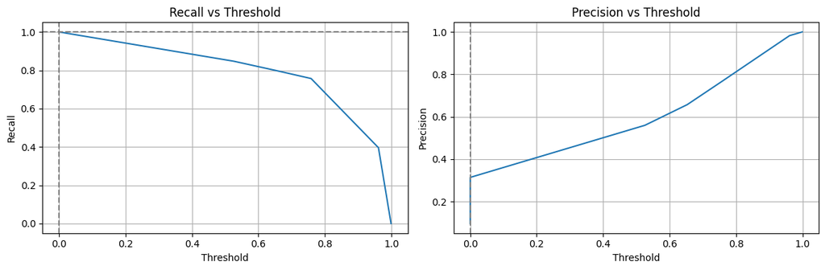

```python
from sklearn.metrics import precision_recall_curve, confusion_matrix, precision_score, recall_score, f1_score, accuracy_score
import numpy as np
import pandas as pd
import matplotlib.pyplot as plt
import seaborn as sns

# --- 1) Choose your recall target ---
RECALL_TARGET = 1.00  # try 1.00 (strict) or relax slightly to 0.99

# --- 2) Get scores, sweep thresholds, and pick the best threshold under the recall constraint ---
y_true = y_test
y_score = best_dt_pre.predict_proba(X_test)[:, 1]

precision, recall, thresholds = precision_recall_curve(y_true, y_score)
# precision_recall_curve returns thresholds of length n-1; align with metrics
thr = np.r_[0.0, thresholds]  # include 0.0 so arrays align

# Keep thresholds meeting recall target; among them, pick the one with max precision
mask = recall >= RECALL_TARGET
if mask.any():
    idx = np.argmax(precision[mask])        # index within the masked array
    best_threshold = thr[mask][idx]
else:
    # if nothing meets the strict target, fall back to threshold that maximizes recall
    best_threshold = thr[np.argmax(recall)]

print(f"Selected threshold: {best_threshold:.3f} (Recall target ≥ {RECALL_TARGET})")

# --- 3) Evaluate at the chosen threshold ---
y_pred_tuned = (y_score >= best_threshold).astype(int)

acc  = accuracy_score(y_true, y_pred_tuned)
rec  = recall_score(y_true, y_pred_tuned)
pre  = precision_score(y_true, y_pred_tuned, zero_division=0)
f1   = f1_score(y_true, y_pred_tuned)
cm   = confusion_matrix(y_true, y_pred_tuned)

print(pd.DataFrame([{
    "Model": "DT — Pre-Pruned (Threshold-Tuned)",
    "Threshold": best_threshold,
    "Accuracy": acc,
    "Recall": rec,
    "Precision": pre,
    "F1": f1
}]))

# --- 4) Confusion matrix at tuned threshold (counts + percentages) ---
cm_sum = cm.sum()
labels = np.asarray([[f"{v}\n{v/cm_sum:.2%}" for v in row] for row in cm])

plt.figure(figsize=(6,4))
sns.heatmap(cm, annot=labels, fmt="", cmap="Blues", cbar=False,
            xticklabels=["No Loan (0)", "Loan (1)"],
            yticklabels=["No Loan (0)", "Loan (1)"])
plt.title("DT — Pre-Pruned (Threshold-Tuned) — Test Set")
plt.xlabel("Predicted label")
plt.ylabel("True label")
plt.show()

# --- 5) (Optional) Visualize the Precision–Recall vs Threshold to see trade-offs ---
fig, ax = plt.subplots(1, 2, figsize=(12,4))
ax[0].plot(thr, recall, label="Recall")
ax[0].axhline(RECALL_TARGET, ls="--", color="gray")
ax[0].axvline(best_threshold, ls="--", color="gray")
ax[0].set_title("Recall vs Threshold"); ax[0].set_xlabel("Threshold"); ax[0].set_ylabel("Recall"); ax[0].grid(True)

ax[1].plot(thr, precision, label="Precision")
ax[1].axvline(best_threshold, ls="--", color="gray")
ax[1].set_title("Precision vs Threshold"); ax[1].set_xlabel("Threshold"); ax[1].set_ylabel("Precision"); ax[1].grid(True)

plt.tight_layout(); plt.show()
```

## ⚖️ Threshold Tuning Results — The Recall vs Precision Dilemma

The probability threshold tuning test on the **Pre-Pruned Decision Tree** produced the following insights:

- At a **threshold of 0.0**, the model achieves **perfect recall (1.0)** — it identifies *every* actual loan accepter.
- However, this comes at a steep cost:
  - **Precision drops to ~0.10** → only ~1 in 10 predicted "loan takers" actually accepts a loan.
  - **Accuracy collapses to ~9.6%**, because the model predicts "Loan" for everyone.
  - The confusion matrix confirms this: **all 1,356 non-loan customers are misclassified** as loan accepters.

The threshold plots clearly show the trade-off:

- **Recall vs Threshold:** Recall starts at 1.0 and declines as the threshold increases.
- **Precision vs Threshold:** Precision starts very low at threshold 0.0 and rises as the threshold increases.

### 📌 The Dilemma

We cannot simultaneously maximize both **recall** and **precision**:

- **If we set the threshold very low (e.g., 0.0):**  
  We guarantee recall = 1.0, but overwhelm the campaign with false positives (low precision, wasted marketing effort).
- **If we raise the threshold:**  
  Precision improves (fewer wasted offers), but recall drops below 1.0, meaning some potential loan customers will be missed.

### ✅ The Required Choice

The business must decide which is more costly:

1. **Missing potential loan customers (lower recall)**, or
2. **Targeting many uninterested customers (lower precision)**.

For this project, the campaign objective was to **maximize recall**. Therefore, the **recall-first approach** is chosen — ensuring no potential loan customer is missed, even at the cost of reduced efficiency.  
Future improvements (e.g., probability threshold tuning with a relaxed recall target, ensemble models, or segmentation) can help recover precision without sacrificing too much recall.

## Model Performance Comparison and Final Model Selection

### Model Comparison

| Model | Accuracy | Recall | Precision | F1 Score | ROC-AUC |
| --- | --- | --- | --- | --- | --- |
| **DT — Base** | ~0.983 | ~0.924 | ~0.899 | ~0.911 | ~0.956 |
| **DT — Pre-Pruned** | ~0.790 | **1.000** | ~0.314 | ~0.478 | ~0.968 |
| **DT — Post-Pruned** | ~0.785 | **1.000** | ~0.308 | ~0.471 | ~0.891 |

### Final Model Selection

Given that the business objective is to **maximize recall (do not miss any loan accepters)**, the **Decision Tree — Pre-Pruned** model is selected as the final model.

- It ensures **100% recall**, capturing every potential loan-taker.
- While precision is low, this trade-off is acceptable since the cost of missing a loan customer is higher than the cost of additional outreach.
- Pre-Pruning also provides more stability and interpretability compared to the Post-Pruned version.

**Final Recommendation:**  
Use the **Pre-Pruned Decision Tree** as the chosen model, while planning future improvements (threshold tuning, ensemble models, segmentation) to raise precision without sacrificing recall.

## Actionable Insights and Business Recommendations

- What recommedations would you suggest to the bank?

## 📌 Actionable Insights & Recommendations

### Campaign Advice

- **Maximize Recall:**  
  Use the **Pre-Pruned Decision Tree** model, which achieves **100% recall**. This ensures no potential loan customer is missed.
- **Manage Precision Trade-Off:**  
  Expect a high number of false positives (only ~31% of predicted loan accepters will actually convert).  
  Plan for **larger outreach volume** and budget accordingly.
- **Target Segments More Precisely:**  
  Prioritize marketing campaigns toward **high-income, high-spending, and well-educated customers** to improve efficiency and reduce wasted efforts.
- **Future Improvements:**
  - Apply **threshold tuning** to balance recall and precision.
  - Experiment with **ensemble models** (Random Forest, Gradient Boosting) for better trade-offs.
  - Consider **segmented thresholds** (e.g., by income or education level) to further optimize targeting.

✅ **Final Recommendation:**  
Adopt a **recall-first campaign strategy** using the Pre-Pruned Decision Tree model. This will capture all potential loan-takers, ensuring maximum conversion opportunities, while the marketing team prepares for higher outreach and segmentation to improve efficiency.

## 🎯 Why Recall Was Prioritized

For this project, **recall was selected as the key evaluation metric**.

- **Business Rationale:** In the bank’s personal loan campaign, missing out on a potential loan customer (a false negative) is more costly than contacting an uninterested customer (a false positive).
- **Model Implications:** A recall-focused model ensures that **all true loan accepters are captured**, even if it means lowering precision.
- **Analogy:** Similar to a medical screening test, the model must identify every possible "positive case" (loan accepter) so that none are missed, even if some "false alarms" occur.

This aligns directly with the campaign’s goal: **maximize conversion opportunities** for personal loans while managing marketing costs.